# 人工智慧 進階課程 - Deep Learning- 課程 14- YOLOv2 Model Training - Racoon Dataset - Python Tutorial

```python
model.summary() # 列印 網絡 模型結構
```

```
__________________________________________________________________________________________________
Layer (type)                    Output Shape         Param #     Connected to
==================================================================================================
input_1 (InputLayer)            (None, 416, 416, 3)  0
__________________________________________________________________________________________________
conv_1 (Conv2D)                 (None, 416, 416, 32) 864         input_1[0][0]
__________________________________________________________________________________________________
norm_1 (BatchNormalization)     (None, 416, 416, 32) 128         conv_1[0][0]
__________________________________________________________________________________________________
leaky_re_lu_1 (LeakyReLU)       (None, 416, 416, 32) 0           norm_1[0][0]
__________________________________________________________________________________________________
max_pooling2d_1 (MaxPooling2D)  (None, 208, 208, 32) 0           leaky_re_lu_1[0][0]
__________________________________________________________________________________________________
conv_2 (Conv2D)                 (None, 208, 208, 64) 18432       max_pooling2d_1[0][0]
__________________________________________________________________________________________________
norm_2 (BatchNormalization)     (None, 208, 208, 64) 256         conv_2[0][0]
__________________________________________________________________________________________________
leaky_re_lu_2 (LeakyReLU)       (None, 208, 208, 64) 0           norm_2[0][0]
__________________________________________________________________________________________________
max_pooling2d_2 (MaxPooling2D)  (None, 104, 104, 64) 0           leaky_re_lu_2[0][0]
__________________________________________________________________________________________________
conv_3 (Conv2D)                 (None, 104, 104, 128 73728       max_pooling2d_2[0][0]
__________________________________________________________________________________________________
norm_3 (BatchNormalization)     (None, 104, 104, 128 512         conv_3[0][0]
__________________________________________________________________________________________________
leaky_re_lu_3 (LeakyReLU)       (None, 104, 104, 128 0           norm_3[0][0]
__________________________________________________________________________________________________
conv_4 (Conv2D)                 (None, 104, 104, 64) 8192        leaky_re_lu_3[0][0]
__________________________________________________________________________________________________
norm_4 (BatchNormalization)     (None, 104, 104, 64) 256         conv_4[0][0]
__________________________________________________________________________________________________
leaky_re_lu_4 (LeakyReLU)       (None, 104, 104, 64) 0           norm_4[0][0]
__________________________________________________________________________________________________
conv_5 (Conv2D)                 (None, 104, 104, 128 73728       leaky_re_lu_4[0][0]
__________________________________________________________________________________________________
norm_5 (BatchNormalization)     (None, 104, 104, 128 512         conv_5[0][0]
__________________________________________________________________________________________________
leaky_re_lu_5 (LeakyReLU)       (None, 104, 104, 128 0           norm_5[0][0]
__________________________________________________________________________________________________
max_pooling2d_3 (MaxPooling2D)  (None, 52, 52, 128)  0           leaky_re_lu_5[0][0]
```

[output cut: 110 more lines]

```
leaky_re_lu_22 (LeakyReLU)      (None, 13, 13, 1024) 0           norm_22[0][0]
__________________________________________________________________________________________________
conv_23 (Conv2D)                (None, 13, 13, 30)   30750       leaky_re_lu_22[0][0]
__________________________________________________________________________________________________
reshape_1 (Reshape)             (None, 13, 13, 5, 6) 0           conv_23[0][0]
__________________________________________________________________________________________________
input_2 (InputLayer)            (None, 1, 1, 1, 50,  0
__________________________________________________________________________________________________
lambda_2 (Lambda)               (None, 13, 13, 5, 6) 0           reshape_1[0][0]
                                                                 input_2[0][0]
==================================================================================================
Total params: 50,578,686
Trainable params: 50,558,014
Non-trainable params: 20,672
__________________________________________________________________________________________________
```

''' >> STEP 3 - 載入預訓練 的模型 - 權重 weights '''

```python
# 讀取 Darknet 預訓練 - 權重檔 weights

weight_reader = WeightReader(wt_path)
```

```python
weight_reader.reset()
nb_conv = 23 # 總 共有 23層的 卷積層

for i in range(1, nb_conv+1):
    conv_layer = model.get_layer('conv_' + str(i))

    # conv_1~conv_22的卷積組合 - 都 包含了 " conv + norm "二層
    # 只有 conv_23 是 獨立一層

    if i < nb_conv:
        print("handle norm_" + str(i) + " start")
        norm_layer = model.get_layer('norm_' + str(i)) # 取得 BatchNormalization層

        size = np.prod(norm_layer.get_weights()[0].shape) # 取得 BatchNormalization層的參數量
        print("shape: ", norm_layer.get_weights()[0].shape)

        beta  = weight_reader.read_bytes(size)
        gamma = weight_reader.read_bytes(size)
        mean  = weight_reader.read_bytes(size)
        var   = weight_reader.read_bytes(size)
        weights = norm_layer.set_weights([gamma, beta, mean, var])
        print("handle norm_" + str(i) + " completed")

    if len(conv_layer.get_weights()) > 1:
        print("handle conv_" + str(i) + " start")
        print("len:",len(conv_layer.get_weights()))
        bias   = weight_reader.read_bytes(np.prod(conv_layer.get_weights()[1].shape))
        kernel = weight_reader.read_bytes(np.prod(conv_layer.get_weights()[0].shape))
        kernel = kernel.reshape(list(reversed(conv_layer.get_weights()[0].shape)))
        kernel = kernel.transpose([2,3,1,0])
        conv_layer.set_weights([kernel, bias])
        print("handle conv_" + str(i) + " completed")
    else:
        print("handle conv_" + str(i) + " start")
        kernel = weight_reader.read_bytes(np.prod(conv_layer.get_weights()[0].shape))
        kernel = kernel.reshape(list(reversed(conv_layer.get_weights()[0].shape)))
        kernel = kernel.transpose([2,3,1,0])
        conv_layer.set_weights([kernel])
        print("handle conv_" + str(i) + " completed")
```

```
handle norm_1 start
shape:  (32,)
handle norm_1 completed
handle conv_1 start
handle conv_1 completed
handle norm_2 start
shape:  (64,)
handle norm_2 completed
handle conv_2 start
handle conv_2 completed
handle norm_3 start
shape:  (128,)
handle norm_3 completed
handle conv_3 start
handle conv_3 completed
handle norm_4 start
shape:  (64,)
handle norm_4 completed
handle conv_4 start
handle conv_4 completed
handle norm_5 start
shape:  (128,)
handle norm_5 completed
handle conv_5 start
handle conv_5 completed
handle norm_6 start
shape:  (256,)
handle norm_6 completed
handle conv_6 start
handle conv_6 completed
handle norm_7 start
shape:  (128,)
handle norm_7 completed
handle conv_7 start
handle conv_7 completed
handle norm_8 start
shape:  (256,)
handle norm_8 completed
handle conv_8 start
handle conv_8 completed
```

[output cut: 58 more lines]

```
handle conv_20 start
handle conv_20 completed
handle norm_21 start
shape:  (64,)
handle norm_21 completed
handle conv_21 start
handle conv_21 completed
handle norm_22 start
shape:  (1024,)
handle norm_22 completed
handle conv_22 start
handle conv_22 completed
handle conv_23 start
len: 2
handle conv_23 completed
```

''' >> STEP 4 - 微調 (fine-tune)的模型層級 權重 weights - YOLOv2的 模型中 - 最後一層卷積層 決定了最後的輸出 - 重新來 調整與訓練 這一層的 卷積層 - 讓預訓練的模型 可以 讓我們進行 - 所需要的微調 '''

```python
layer   = model.layers[-4] # 找出 最後一層的 卷積層
weights = layer.get_weights()

new_kernel = np.random.normal(size=weights[0].shape)/(GRID_H*GRID_W)
new_bias   = np.random.normal(size=weights[1].shape)/(GRID_H*GRID_W)

layer.set_weights([new_kernel, new_bias]) # 重初始化權重
```

''' >> STEP 5 - 模型 訓練 '''

**YOLOv2訓練用的損失函數:**

$$\begin{multline} \lambda_\textbf{coord} \sum_{i = 0}^{S^2} \sum_{j = 0}^{B} L_{ij}^{\text{obj}} \left[ \left( x_i - \hat{x}_i \right)^2 + \left( y_i - \hat{y}_i \right)^2 \right] \\ + \lambda_\textbf{coord} \sum_{i = 0}^{S^2} \sum_{j = 0}^{B} L_{ij}^{\text{obj}} \left[ \left( \sqrt{w_i} - \sqrt{\hat{w}_i} \right)^2 + \left( \sqrt{h_i} - \sqrt{\hat{h}_i} \right)^2 \right] \\ + \sum_{i = 0}^{S^2} \sum_{j = 0}^{B} L_{ij}^{\text{obj}} \left( C_i - \hat{C}_i \right)^2 \\ + \lambda_\textrm{noobj} \sum_{i = 0}^{S^2} \sum_{j = 0}^{B} L_{ij}^{\text{noobj}} \left( C_i - \hat{C}_i \right)^2 \\ + \sum_{i = 0}^{S^2} L_i^{\text{obj}} \sum_{c \in \textrm{classes}} \left( p_i(c) - \hat{p}_i(c) \right)^2 \end{multline}$$

```python
def custom_loss(y_true, y_pred):
    mask_shape = tf.shape(y_true)[:4]

    cell_x = tf.to_float(tf.reshape(tf.tile(tf.range(GRID_W), [GRID_H]), (1, GRID_H, GRID_W, 1, 1)))
    cell_y = tf.transpose(cell_x, (0,2,1,3,4))

    cell_grid = tf.tile(tf.concat([cell_x,cell_y], -1), [BATCH_SIZE, 1, 1, 5, 1])

    coord_mask = tf.zeros(mask_shape)
    conf_mask  = tf.zeros(mask_shape)
    class_mask = tf.zeros(mask_shape)

    seen = tf.Variable(0.)
    total_recall = tf.Variable(0.)

    """
    Adjust prediction
    """
    ### adjust x and y
    pred_box_xy = tf.sigmoid(y_pred[..., :2]) + cell_grid

    ### adjust w and h
    pred_box_wh = tf.exp(y_pred[..., 2:4]) * np.reshape(ANCHORS, [1,1,1,BOX,2])

    ### adjust confidence
    pred_box_conf = tf.sigmoid(y_pred[..., 4])

    ### adjust class probabilities
    pred_box_class = y_pred[..., 5:]

    """
    Adjust ground truth
    """
    ### adjust x and y
    true_box_xy = y_true[..., 0:2] # relative position to the containing cell

    ### adjust w and h
    true_box_wh = y_true[..., 2:4] # number of cells accross, horizontally and vertically

    ### adjust confidence
    true_wh_half = true_box_wh / 2.
    true_mins    = true_box_xy - true_wh_half
    true_maxes   = true_box_xy + true_wh_half

    pred_wh_half = pred_box_wh / 2.
    pred_mins    = pred_box_xy - pred_wh_half
    pred_maxes   = pred_box_xy + pred_wh_half

    intersect_mins  = tf.maximum(pred_mins,  true_mins)
    intersect_maxes = tf.minimum(pred_maxes, true_maxes)
    intersect_wh    = tf.maximum(intersect_maxes - intersect_mins, 0.)
    intersect_areas = intersect_wh[..., 0] * intersect_wh[..., 1]

    true_areas = true_box_wh[..., 0] * true_box_wh[..., 1]
    pred_areas = pred_box_wh[..., 0] * pred_box_wh[..., 1]

    union_areas = pred_areas + true_areas - intersect_areas
    iou_scores  = tf.truediv(intersect_areas, union_areas)

    true_box_conf = iou_scores * y_true[..., 4]

    ### adjust class probabilities
    true_box_class = tf.argmax(y_true[..., 5:], -1)

    """
    Determine the masks
    """
    ### coordinate mask: simply the position of the ground truth boxes (the predictors)
    coord_mask = tf.expand_dims(y_true[..., 4], axis=-1) * COORD_SCALE

    ### confidence mask: penelize predictors + penalize boxes with low IOU
    # penalize the confidence of the boxes, which have IOU with some ground truth box < 0.6
    true_xy = true_boxes[..., 0:2]
    true_wh = true_boxes[..., 2:4]

    true_wh_half = true_wh / 2.
    true_mins    = true_xy - true_wh_half
    true_maxes   = true_xy + true_wh_half

    pred_xy = tf.expand_dims(pred_box_xy, 4)
    pred_wh = tf.expand_dims(pred_box_wh, 4)

    pred_wh_half = pred_wh / 2.
    pred_mins    = pred_xy - pred_wh_half
    pred_maxes   = pred_xy + pred_wh_half

    intersect_mins  = tf.maximum(pred_mins,  true_mins)
    intersect_maxes = tf.minimum(pred_maxes, true_maxes)
    intersect_wh    = tf.maximum(intersect_maxes - intersect_mins, 0.)
    intersect_areas = intersect_wh[..., 0] * intersect_wh[..., 1]

    true_areas = true_wh[..., 0] * true_wh[..., 1]
    pred_areas = pred_wh[..., 0] * pred_wh[..., 1]

    union_areas = pred_areas + true_areas - intersect_areas
    iou_scores  = tf.truediv(intersect_areas, union_areas)

    best_ious = tf.reduce_max(iou_scores, axis=4)
    conf_mask = conf_mask + tf.to_float(best_ious < 0.6) * (1 - y_true[..., 4]) * NO_OBJECT_SCALE

    # penalize the confidence of the boxes, which are reponsible for corresponding ground truth box
    conf_mask = conf_mask + y_true[..., 4] * OBJECT_SCALE

    ### class mask: simply the position of the ground truth boxes (the predictors)
    class_mask = y_true[..., 4] * tf.gather(CLASS_WEIGHTS, true_box_class) * CLASS_SCALE

    """
    Warm-up training
    """
    no_boxes_mask = tf.to_float(coord_mask < COORD_SCALE/2.)
    seen = tf.assign_add(seen, 1.)

    true_box_xy, true_box_wh, coord_mask = tf.cond(tf.less(seen, WARM_UP_BATCHES),
                          lambda: [true_box_xy + (0.5 + cell_grid) * no_boxes_mask,
                                   true_box_wh + tf.ones_like(true_box_wh) * np.reshape(ANCHORS, [1,1,1,BOX,2]) * no_boxes_mask,
                                   tf.ones_like(coord_mask)],
                          lambda: [true_box_xy,
                                   true_box_wh,
                                   coord_mask])

    """
    Finalize the loss
    """
    nb_coord_box = tf.reduce_sum(tf.to_float(coord_mask > 0.0))
    nb_conf_box  = tf.reduce_sum(tf.to_float(conf_mask  > 0.0))
    nb_class_box = tf.reduce_sum(tf.to_float(class_mask > 0.0))

    loss_xy    = tf.reduce_sum(tf.square(true_box_xy-pred_box_xy)     * coord_mask) / (nb_coord_box + 1e-6) / 2.
    loss_wh    = tf.reduce_sum(tf.square(true_box_wh-pred_box_wh)     * coord_mask) / (nb_coord_box + 1e-6) / 2.
    loss_conf  = tf.reduce_sum(tf.square(true_box_conf-pred_box_conf) * conf_mask)  / (nb_conf_box  + 1e-6) / 2.
    loss_class = tf.nn.sparse_softmax_cross_entropy_with_logits(labels=true_box_class, logits=pred_box_class)
    loss_class = tf.reduce_sum(loss_class * class_mask) / (nb_class_box + 1e-6)

    loss = loss_xy + loss_wh + loss_conf + loss_class

    nb_true_box = tf.reduce_sum(y_true[..., 4])
    nb_pred_box = tf.reduce_sum(tf.to_float(true_box_conf > 0.5) * tf.to_float(pred_box_conf > 0.3))

    """
    Debugging code
    """
    current_recall = nb_pred_box/(nb_true_box + 1e-6)
    total_recall = tf.assign_add(total_recall, current_recall)

    loss = tf.Print(loss, [tf.zeros((1))], message='Dummy Line \t', summarize=1000)
    loss = tf.Print(loss, [loss_xy], message='Loss XY \t', summarize=1000)
    loss = tf.Print(loss, [loss_wh], message='Loss WH \t', summarize=1000)
    loss = tf.Print(loss, [loss_conf], message='Loss Conf \t', summarize=1000)
    loss = tf.Print(loss, [loss_class], message='Loss Class \t', summarize=1000)
    loss = tf.Print(loss, [loss], message='Total Loss \t', summarize=1000)
    loss = tf.Print(loss, [current_recall], message='Current Recall \t', summarize=1000)
    loss = tf.Print(loss, [total_recall/seen], message='Average Recall \t', summarize=1000)

    return loss
```

''' >> 產生 Keras 訓練模型的 BatchGenerator 的設定 '''

```python
generator_config = {
    'IMAGE_H'         : IMAGE_H,      # YOLOv2 網絡輸入的 image_h
    'IMAGE_W'         : IMAGE_W,      # YOLOv2 網絡輸入的 image_w
    'GRID_H'          : GRID_H,       # 直向網格的 拆分數量
    'GRID_W'          : GRID_W,       # 橫向網格的 拆分數量
    'BOX'             : BOX,          # 每個單一網格要預測的 邊界框 數量
    'LABELS'          : LABELS,       # 要預測的 圖像種類 列表
    'CLASS'           : len(LABELS),  # 要預測的圖像 種類數
    'ANCHORS'         : ANCHORS,      # 每個單一網格要預測的邊界框時用的 錨點
    'BATCH_SIZE'      : BATCH_SIZE,   # 訓練時的 批量數
    'TRUE_BOX_BUFFER' : 50,           # 一個訓練圖像 最大數量的 邊界框數
}
```

''' - preprocessing.py中 - 有一個函式 parse_annotation - 是用來解析 PASCAL VOC格式的 圖像標註檔 - 這個函式的邏輯與定義: - 解析 PASCAL VOC格式的 圖像標註檔 - 根據 PASCAL VOC標註檔存放的目錄路徑 - 迭代地解析每一個標註檔 - 將每個圖像的 - 檔名(filename) - 圖像的寬(width) - 高(height) - 圖像的類別(name)以 - 物體的邊界框的坐標(xmin,ymin,xmax,ymax) - 擷取出來 - 參數: - ann_dir : PASCAL VOC標註檔存放的 目錄路徑 - img_dir : 圖像檔存放的 目錄路徑 - labels : 圖像資料集的物體類別 列表 回傳: - all_imgs: 一個列表物件, 每一個物件都包括了要訓練用的重要資訊。例如: { 'filename': '/tmp/img/img001.jpg', 'width': 128, 'height': 128, 'object':[ {'name':'person',xmin:0, ymin:0, xmax:28, ymax:28}, {'name':'person',xmin:45, ymin:45, xmax:60, ymax:60} ] } - seen_labels: 一個字典物件(k:圖像類別, v:出現的次數) - 用來 檢視每一個圖像類別 出現的 次數

```python
# 進行圖像標註檔的解析 ( Racoon資料集的標註 - 採用的是 PASCAL VOC - XML 格式 )

train_imgs, seen_train_labels = parse_annotation(train_annot_folder, train_image_folder, labels=LABELS)

# 建立一個訓練用的 - 資料產生器
train_batch = BatchGenerator(train_imgs, generator_config, norm=normalize)

# 進行圖像標註檔的 解析 (Racoon資料集的標註 - 採用的 是 PASCAL VOC -0 XML格式 )
valid_imgs, seen_valid_labels = parse_annotation(valid_annot_folder, valid_image_folder, labels=LABELS)

# 建立一個驗證用的 - 資料產生器
valid_batch = BatchGenerator(valid_imgs, generator_config, norm=normalize, jitter=False)
```

```
C:\Users\Mike Liang\Anaconda3\envs\Python3.6.7\lib\site-packages\imgaug\imgaug.py:182: DeprecationWarning: Function `ContrastNormalization()` is deprecated. Use `imgaug.contrast.LinearContrast` instead.
  warn_deprecated(msg, stacklevel=3)
```

''' >> 設置一些 回調函式 - early_stop - checkpoint '''

```python
# 如果 超過 15次 的循環 在 loss的 收歛上 - 沒有改善 - 停止訓練

early_stop = EarlyStopping(monitor='val_loss',
                           min_delta=0.001,
                           patience=15, # 如果 超過 15次 的循環 在 loss的 收歛上 - 沒有改善 - 停止訓練
                           mode='min',
                           verbose=1)

# 每次的訓練循 都去比較模型的 loss 是否有改善, 有就把模型的權重 儲存下來

checkpoint = ModelCheckpoint('weights_racoon.h5',
                             monitor='val_loss',
                             verbose=1,
                             save_best_only=True,
                             mode='min',
                             period=1)
```

''' >> 開始訓練 '''

```python
%%time


optimizer = Adam(lr=0.5e-4, beta_1=0.9, beta_2=0.999, epsilon=1e-08, decay=0.0)
#optimizer = SGD(lr=1e-4, decay=0.0005, momentum=0.9)
#optimizer = RMSprop(lr=1e-4, rho=0.9, epsilon=1e-08, decay=0.0)

model.compile(loss=custom_loss, optimizer=optimizer)

history = model.fit_generator(generator = train_batch,
                    steps_per_epoch  = len(train_batch),
                    epochs           = 200, # 進行200個訓練循環
                    verbose          = 1,
                    validation_data  = valid_batch,
                    validation_steps = len(valid_batch),
                    callbacks        = [early_stop, checkpoint],
                    max_queue_size   = 3)
```

```
Wall time: 0 ns
```

[output not shown]

```
Epoch 00001: val_loss improved from inf to 1.24005, saving model to weights_racoon.h5

Epoch 00002: val_loss improved from 1.24005 to 0.78858, saving model to weights_racoon.h5

Epoch 00003: val_loss improved from 0.78858 to 0.68174, saving model to weights_racoon.h5

Epoch 00004: val_loss improved from 0.68174 to 0.55357, saving model to weights_racoon.h5

Epoch 00005: val_loss improved from 0.55357 to 0.49675, saving model to weights_racoon.h5

Epoch 00006: val_loss improved from 0.49675 to 0.38578, saving model to weights_racoon.h5

Epoch 00007: val_loss did not improve from 0.38578

Epoch 00008: val_loss improved from 0.38578 to 0.35341, saving model to weights_racoon.h5

Epoch 00009: val_loss improved from 0.35341 to 0.29681, saving model to weights_racoon.h5

Epoch 00010: val_loss did not improve from 0.29681

Epoch 00011: val_loss improved from 0.29681 to 0.29577, saving model to weights_racoon.h5

Epoch 00012: val_loss did not improve from 0.29577

Epoch 00013: val_loss did not improve from 0.29577

Epoch 00014: val_loss did not improve from 0.29577

Epoch 00015: val_loss did not improve from 0.29577

Epoch 00016: val_loss improved from 0.29577 to 0.27076, saving model to weights_racoon.h5

Epoch 00017: val_loss did not improve from 0.27076

Epoch 00018: val_loss did not improve from 0.27076

Epoch 00019: val_loss improved from 0.27076 to 0.22658, saving model to weights_racoon.h5

Epoch 00020: val_loss improved from 0.22658 to 0.21136, saving model to weights_racoon.h5

```

[output cut: 295 more lines]

```

Epoch 00169: val_loss did not improve from 0.04266

Epoch 00170: val_loss did not improve from 0.04266

Epoch 00171: val_loss did not improve from 0.04266

Epoch 00172: val_loss improved from 0.04266 to 0.04186, saving model to weights_racoon.h5

Epoch 00173: val_loss did not improve from 0.04186

Epoch 00174: val_loss did not improve from 0.04186

Epoch 00175: val_loss did not improve from 0.04186
Epoch 00175: early stopping
```

''' >> STEP 6 - 進行圖像的 偵測 - 訓練圖像 - 隨機選一張圖像 - 來進行偵測 '''

```python
# 載入 訓練好的 - 模型權重

model.load_weights("weights_racoon.h5")
```

```python
# 產生一個 Dummy的 標籤輸入

# 訓練階段 真實的邊界框與圖像類別訊息
# 預測階段 需要有一個Dummy的輸入
# 定義在網絡的結構中 有兩個輸入：
#   1. - 圖像的輸人
#   2. - 圖像邊界框 /錨點 /信心分數的 輸入

dummy_array = np.zeros((1,1,1,1,TRUE_BOX_BUFFER,4))
```

```
C:\Users\Mike Liang\Desktop\AdvancedCourse\YoLoDetection\3.2-yolov2-train_racoon_dataset\data\racoon\images\raccoon-160.jpg
```

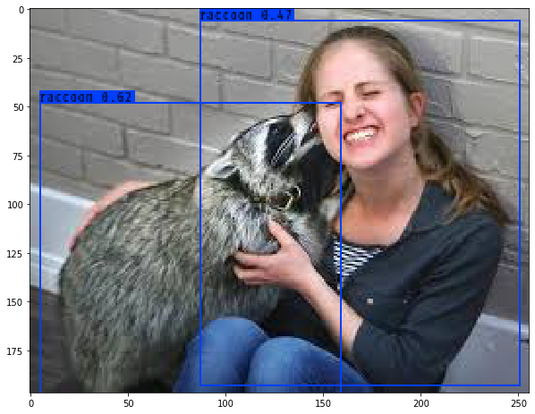

```python
# 隨機 － 選一張圖像

img_filepath = train_imgs[np.random.randint(len(train_imgs))]['filename']

print(img_filepath)

# OpenCV 讀入圖像
image = cv2.imread(img_filepath)

plt.figure(figsize=(10,10))

# 進行圖像輸入的 - 預處理
input_image = cv2.resize(image, (416, 416))     # 修改輸入圖像大小 - 符合模型 的要求
input_image = input_image / 255.                # 進行圖像 歸一處理
input_image = np.expand_dims(input_image, 0)    # 增加 batch dimension

# 進行 圖像偵測

netout = model.predict([input_image, dummy_array])

# 解析網絡的輸出 來 取得最後偵測出來的  邊界框(bounding boxes) 列表 List

boxes = decode_netout(netout[0],
                      obj_threshold=OBJ_THRESHOLD,
                      #obj_threshold=0.3,
                      nms_threshold=NMS_THRESHOLD,
                      #nms_threshold=0.001,
                      anchors=ANCHORS,
                      nb_class=CLASS)

# -  draw_bgr_image_boxes - "
#
# 一個簡單 把邊界框與預測結果打印到原始圖像(BGR)上的工具函式
# 參數: image 是image的numpy ndarray [h, w, channels(BGR)]
#       boxes 是偵測的結果
#       labels 是模型訓練的圖像類別列表
# 回傳： image 是image的numpy ndarray [h, w, channels(RGB)]
#

image = draw_bgr_image_boxes(image, boxes, labels=LABELS)

# 結果 顯示出來

plt.imshow(image)
plt.show()
```

```
C:\Users\Mike Liang\Desktop\AdvancedCourse\YoLoDetection\3.2-yolov2-train_racoon_dataset\data\racoon\images\raccoon-1.jpg
```

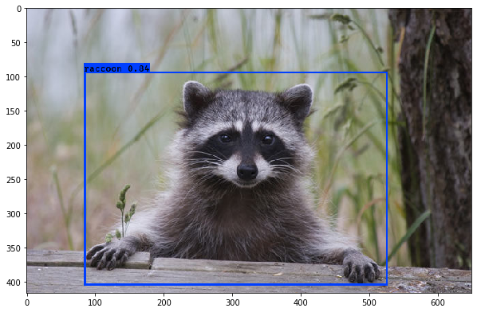

```python
# 選一張圖像

# img_filepath = train_imgs[np.random.randint(len(train_imgs))]['filename']

img_filepath = os.path.join(IMAGES_PATH,"raccoon-1.jpg")
print(img_filepath)

# OpenCV 讀入圖像
image = cv2.imread(img_filepath)

plt.figure(figsize=(10,10))

# 進行圖像輸入的 - 預處理
input_image = cv2.resize(image, (416, 416))     # 修改輸入圖像大小 - 符合模型 的要求
input_image = input_image / 255.                # 進行圖像 歸一處理
input_image = np.expand_dims(input_image, 0)    # 增加 batch dimension

# 進行 圖像偵測

netout = model.predict([input_image, dummy_array])

# 解析網絡的輸出 來 取得最後偵測出來的  邊界框(bounding boxes) 列表 List

boxes = decode_netout(netout[0],
                      obj_threshold=OBJ_THRESHOLD,
                      #obj_threshold=0.3,
                      nms_threshold=NMS_THRESHOLD,
                      #nms_threshold=0.001,
                      anchors=ANCHORS,
                      nb_class=CLASS)

# -  draw_bgr_image_boxes - "
#
# 一個簡單 把邊界框與預測結果打印到原始圖像(BGR)上的工具函式
# 參數: image 是image的numpy ndarray [h, w, channels(BGR)]
#       boxes 是偵測的結果
#       labels 是模型訓練的圖像類別列表
# 回傳： image 是image的numpy ndarray [h, w, channels(RGB)]
#

image = draw_bgr_image_boxes(image, boxes, labels=LABELS)

# 結果 顯示出來

plt.imshow(image)
plt.show()
```

```python
參考文獻:

- YOLO 官網                        (https://pjreddie.com/darknet/yolo/)
- llSourcell/YOLO_Object_Detection (https://github.com/llSourcell/YOLO_Object_Detection)
- experiencor/raccoon_dataset      (https://github.com/experiencor/raccoon_dataset)
```